# Process Mining Hip Replacement Pathways

Jenny Cooper

26/04/2021

### 1 Process Mining for Patients on a Hip Replacement Pathway

##### 1.1 Activity Frequency

The table below summarises the frequency and relative frequency of the activities involved in the hip replacement pathway identified from the event log.

| activity | absolute | relative |
| --- | --- | --- |
| OP_trauma and orthopaedic service | 2402 | 0.4605944 |
| APPT_made | 705 | 0.1351870 |
| elec_hip_replace | 705 | 0.1351870 |
| GP_refers_for_hip | 705 | 0.1351870 |
| primarycare_msk | 227 | 0.0435283 |
| primary_care_analgesic | 214 | 0.0410355 |
| OP_physiotherapy service | 74 | 0.0141898 |
| OP_diagnostic imaging service | 56 | 0.0107383 |
| AE | 48 | 0.0092042 |
| community_musculoskeletal service | 34 | 0.0065197 |
| OP_pain management service | 14 | 0.0026846 |
| OP_rheumatology service | 13 | 0.0024928 |
| OP_anaesthetic service | 11 | 0.0021093 |
| community_physiotherapy service | 7 | 0.0013423 |

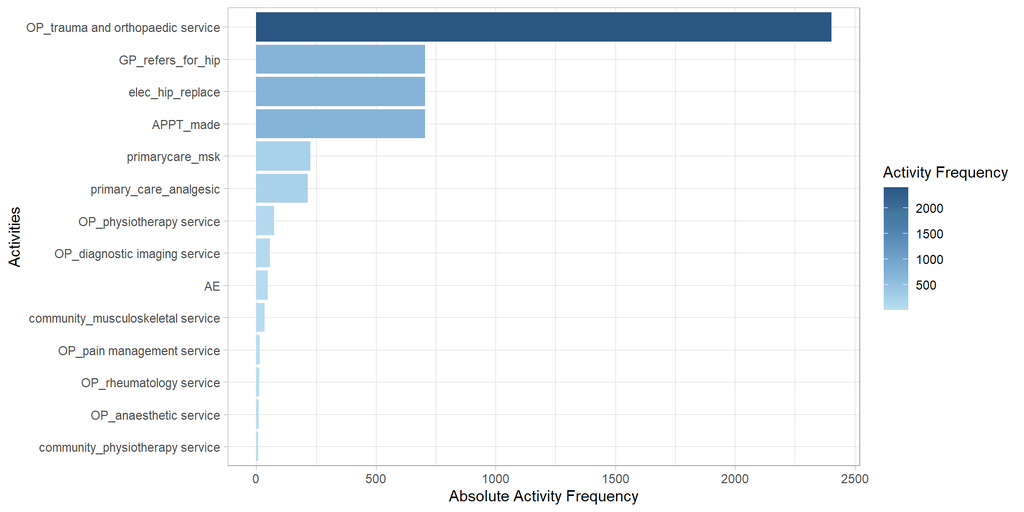

##### 1.2 Process Maps

The identified activities in the event log can be plotted in a process map which can be annotated with different information. For instance the process map below shows the frequencies of activities and flows. This shows a restricted set of activities for illustration purposes.

[interactive chart not shown]

The next process map shows the event log from a performance perspective i.e. summarising the processing time of activities taking the median in this instance). This shows a restricted set of activities for illustration purposes.

[interactive chart not shown]

User defined measures can also be included. The process map below shows the average cost (median) of the different activities as well as the frequencies between them. This shows a restricted set of activities for illustration purposes.

[interactive chart not shown]

The final process map shows all the selected activities and combines both frequencies and processing time.

[interactive chart not shown]

##### 1.3 Animated Process Maps

Each token in the process map below represents a patient following their own trace (or pathway) over time. The tokens can be coloured by different attributes for instance here orange reflects patients who are 50 and over and yellow tokens represent patients less than 50.

[interactive chart not shown]

##### 1.4 Process Discovery Heuristics Miner

The plot below shows the dependency values for pairs of activities. These are used for setting the dependency thresholds for the model.

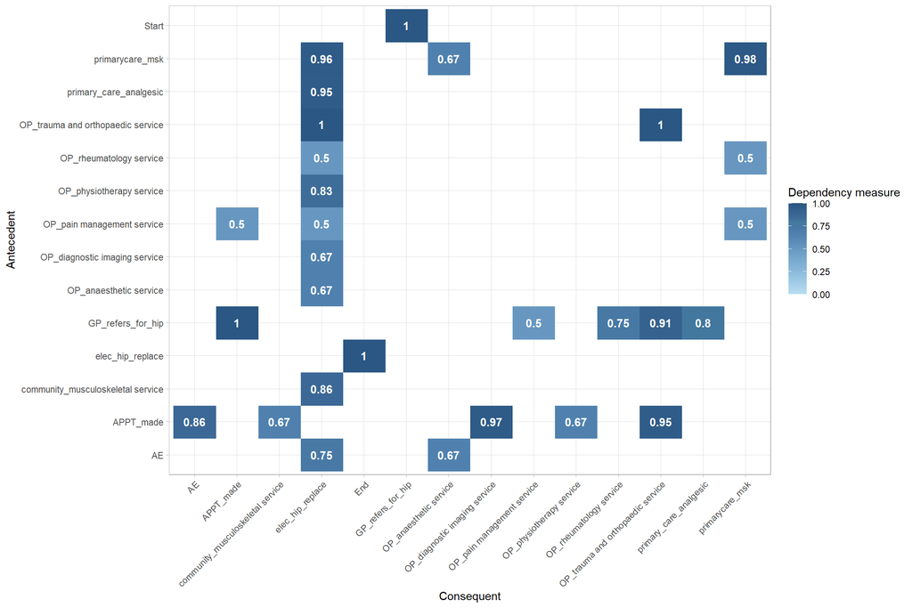

The following creates a dependency graph/matrix for the Heuristics Miner algorithm using a dependency threshold of 0.5.

[interactive chart not shown]

The following creates a dependency graph/matrix for the Heuristics Miner algorithm but using a dependency threshold of 0.6. We see that not all the activities are joined up hence the 0.5 threshold is taken forward.

[interactive chart not shown]

There are other parameters to the Heuristics Miner algorithm including from the Flexible Heuristics Miner (FHM) ‘all_connected’ argument. This means the best antecedent and consequent (as determined by the dependency measure) will be added regardless of the threshold value [See heuristicsmineR documentation](https://cran.r-project.org/web/packages/heuristicsmineR/index.html)

[interactive chart not shown]

The plot below shows the causal graph otherwise known as the heuristics net for a dependency threshold of 0.5.

[interactive chart not shown]

##### 1.5 Process Discovery Inductive Miner

The plots below show the resulting petri net discovered using the inductive mining algorithm (inductive miner directly follows algorithm) and after rendering to DOT format.

The process model discovered using the inductive mining algorithm consists of a petri net, an initial marking and a final marking.

```
## List of 3
##  $ petrinet       :List of 4
##   ..$ places     :'data.frame':  7 obs. of  1 variable:
##   .. ..$ id: chr [1:7] "p_4" "p_6" "sink" "p_7" ...
##   ..$ transitions:'data.frame':  20 obs. of  2 variables:
##   .. ..$ id   : chr [1:20] "skip_6" "2156bf70-f345-44e6-bb5c-ea46828c7e75" "1be63127-9f13-4e7b-b254-e9db2a510313" "loop_4" ...
##   .. ..$ label: chr [1:20] NA "AE" "community_musculoskeletal service" NA ...
##   ..$ flows      :'data.frame':  40 obs. of  2 variables:
##   .. ..$ from: chr [1:40] "p_5" "tau_1" "p_5" "p_6" ...
##   .. ..$ to  : chr [1:40] "69b6f069-d139-4929-8145-99ca236ecfc9" "p_3" "279d8ecf-4cf7-40b9-803f-c8d5c96d2665" "skip_6" ...
##   ..$ marking    : chr "source"
##   ..- attr(*, "class")= chr "petrinet"
##  $ initial_marking: chr "source"
##  $ final_marking  : chr "sink"
```

```
## [1] "petrinet"
```

[interactive chart not shown]

```
## [1] "pm4py.objects.petri.petrinet.PetriNet"
## [2] "python.builtin.object"
```

[interactive chart not shown]

We can use the event log data to compute the alignments by comparing with the model outputs. The alignment table can be used to compare the log_label and the model_label to determine when a move is synchronous.

The quality of the model can be determined by replaying the eventlog data over the discovered model. Fitness in this instance is 100% which means the model fits the data well.

Other measures are also calculated including precision, generalisation, simplicity, average weight and fscore. [pm4py documentation for quality measures](https://pm4py.fit.fraunhofer.de/documentation#evaluation)

```
## $fitness
## $fitness$perc_fit_traces
## [1] 100
##
## $fitness$average_trace_fitness
## [1] 1
##
## $fitness$log_fitness
## [1] 1
##
##
## $precision
## [1] 0.2388851
##
## $generalization
## [1] 0.8880824
##
## $simplicity
## [1] 0.509434
##
## $metricsAverageWeight
## [1] 0.6591004
##
## $fscore
## [1] 0.3856453
```